# GNET - 4E & diff judgements - basic analysis

# GNET - 4 elements with difference ratings from participants

This is the analysis of the second run of GNET4E. Everything is the same, except that in the study phase participants looked at a familiar first then a novel and rated the subjective difference of the images.

As in the original task, stimuli were algorithmically generated, allowing precise comparison between stimuli. The difference between the stimulus presented and other stimuli (several comparisons are used) is a proxy for novelty.

During familiarization, participants learned a set of 5 stimuli During the study phase, they rated the difference of these stimuli to novels. During the test phase, the performed a recognition memory test for the novels intermixed with distractors. - Novels and distractors were balanced.

In the original GNET, recognition performance tended to increase monotonically with difference to familiars In the GNET4E participants showed their highest categorization performance for stimuli at intermediate levels of difference.

# Exclusions

The task was started 67 times.

This left 46 participants in the analysis.

The identifiers are:

501_179, 503_180, 504_190, 505_189, 506_181, 507_187, 508_192, 510_191, 511_193, 514_198, 515_199, 516_200, 517_202, 518_204, 519_203, 520_205, 522_207, 523_208, 524_210, 526_212, 527_213, 528_214, 529_215, 530_240, 531_253, 532_259, 533_262, 534_308, 535_323, 536_324, 539_342, 540_343, 543_367, 544_371, 547_385, 551_407, 554_423, 557_435, 559_449, 560_451, 561_453, 562_456, 564_458, 565_459, 566_462, 567_465

# Study phase

Participants make a judgement of the difference between a prototype and a novel picture.

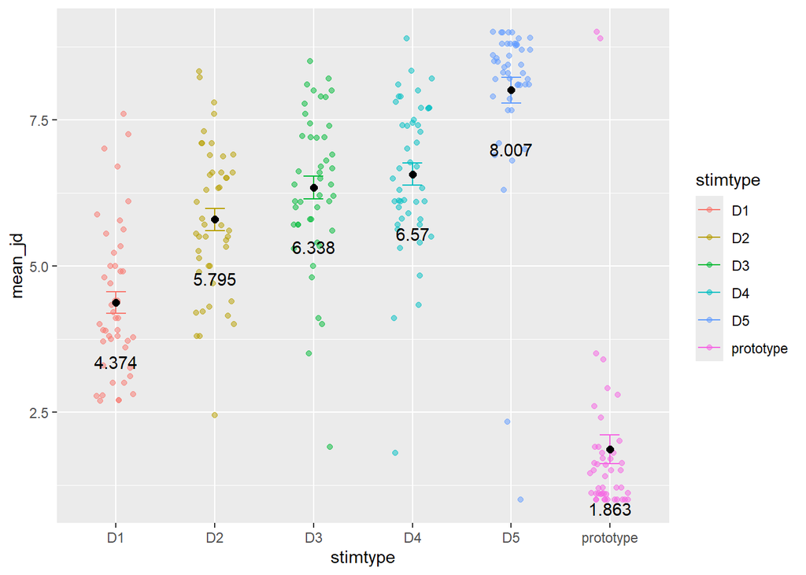

# Test phase

Test phase was the same as before: participants see the novel pictures from the study phase with distractors from the same categories. They signal if they think the picture is an old one from the study phase, or a novel distractor.

```
## [1] "Correct recognition for familiars in test"
```

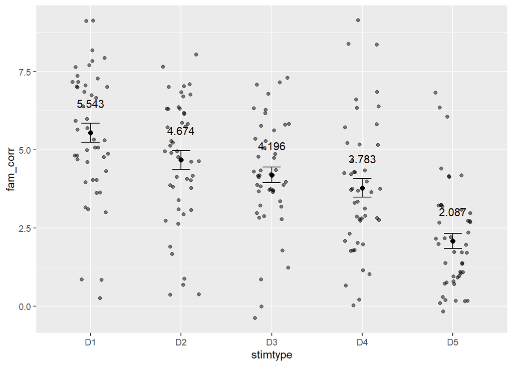

```
## [1] "False alarm for novels in test"
```

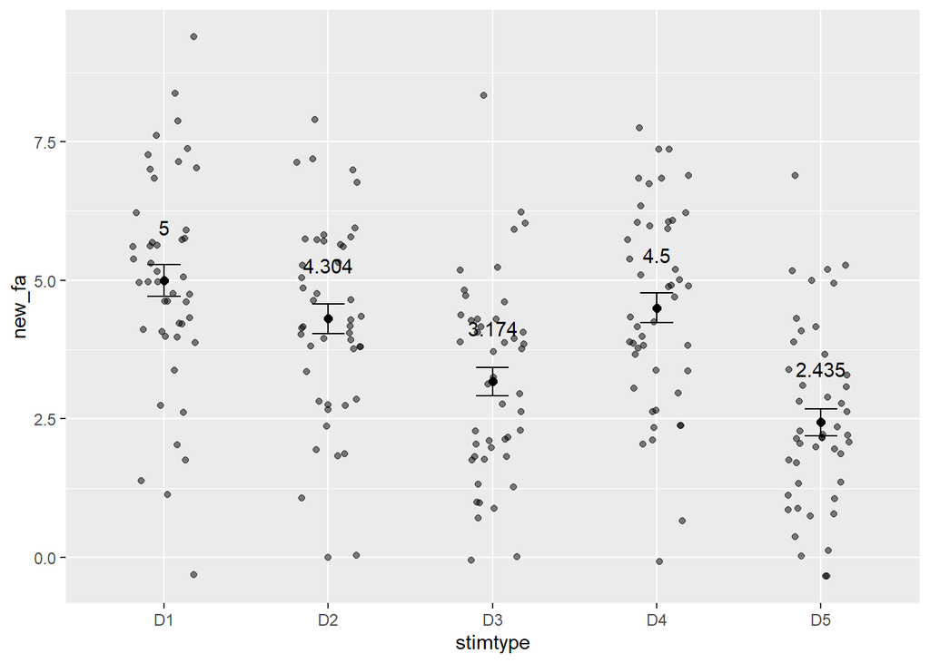

```
## [1] "ANOVA with correct recognition minus false alarm or miss by fam/nov"
```

```
## Anova Table (Type 3 tests)
##
## Response: CorrectedRecognitions
##     Effect           df  MSE        F  ges p.value
## 1 stimtype 3.74, 168.18 3.76 6.41 *** .098   <.001
## ---
## Signif. codes:  0 '***' 0.001 '**' 0.01 '*' 0.05 '+' 0.1 ' ' 1
##
## Sphericity correction method: GG
```

```
##  contrast estimate    SE df t.ratio p.value
##  D1 - D2     0.174 0.441 45   0.394  0.9947
##  D1 - D3    -0.478 0.430 45  -1.111  0.7998
##  D1 - D4     1.261 0.386 45   3.264  0.0171
##  D1 - D5     0.891 0.375 45   2.379  0.1398
##  D2 - D3    -0.652 0.429 45  -1.521  0.5544
##  D2 - D4     1.087 0.383 45   2.838  0.0504
##  D2 - D5     0.717 0.343 45   2.092  0.2412
##  D3 - D4     1.739 0.377 45   4.608  0.0003
##  D3 - D5     1.370 0.396 45   3.458  0.0100
##  D4 - D5    -0.370 0.335 45  -1.102  0.8045
##
## P value adjustment: tukey method for comparing a family of 5 estimates
```

```
##  contrast  estimate    SE df t.ratio p.value
##  linear       -2.87 0.792 45  -3.622  0.0007
##  quadratic    -1.30 1.070 45  -1.213  0.2313
##  cubic         1.28 0.899 45   1.427  0.1604
##  quartic       7.72 2.360 45   3.266  0.0021
```

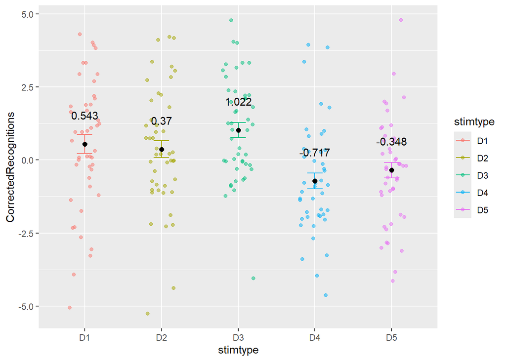

```
## [1] "ANOVA with correct rejection minus false alarm or miss by fam/nov"
```

```
## Anova Table (Type 3 tests)
##
## Response: CorrectedRejections
##     Effect           df  MSE        F  ges p.value
## 1 stimtype 3.64, 163.91 4.51 7.61 *** .122   <.001
## ---
## Signif. codes:  0 '***' 0.001 '**' 0.01 '*' 0.05 '+' 0.1 ' ' 1
##
## Sphericity correction method: GG
```

```
##  contrast estimate    SE df t.ratio p.value
##  D1 - D2     0.174 0.417 45   0.417  0.9935
##  D1 - D3    -0.674 0.467 45  -1.442  0.6044
##  D1 - D4     1.457 0.351 45   4.146  0.0013
##  D1 - D5     0.891 0.392 45   2.272  0.1729
##  D2 - D3    -0.848 0.446 45  -1.901  0.3319
##  D2 - D4     1.283 0.406 45   3.159  0.0225
##  D2 - D5     0.717 0.401 45   1.788  0.3932
##  D3 - D4     2.130 0.481 45   4.428  0.0006
##  D3 - D5     1.565 0.471 45   3.323  0.0146
##  D4 - D5    -0.565 0.370 45  -1.528  0.5503
##
## P value adjustment: tukey method for comparing a family of 5 estimates
```

```
##  contrast  estimate    SE df t.ratio p.value
##  linear       -3.07 0.853 45  -3.595  0.0008
##  quadratic    -1.50 1.140 45  -1.310  0.1968
##  cubic         1.67 0.931 45   1.798  0.0789
##  quartic       9.67 2.700 45   3.585  0.0008
```

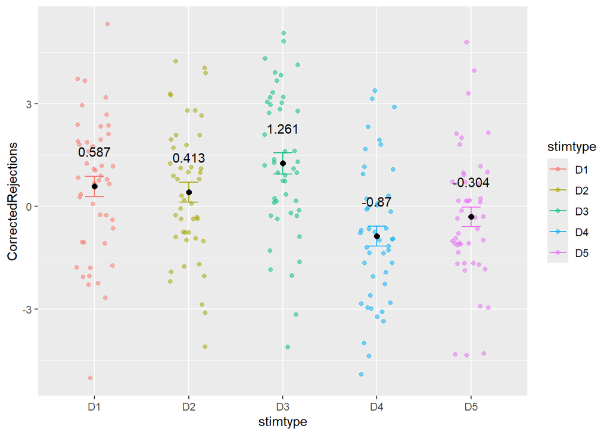

```
## [1] "ANOVA with corrected differentiation score by category ((crecog-fa)+(creject-fa))"
```

```
## Anova Table (Type 3 tests)
##
## Response: OCCategorizations
##     Effect           df   MSE        F  ges p.value
## 1 stimtype 3.78, 170.09 14.80 7.63 *** .119   <.001
## ---
## Signif. codes:  0 '***' 0.001 '**' 0.01 '*' 0.05 '+' 0.1 ' ' 1
##
## Sphericity correction method: GG
```

```
##  contrast estimate    SE df t.ratio p.value
##  D1 - D2     0.348 0.821 45   0.423  0.9930
##  D1 - D3    -1.152 0.854 45  -1.349  0.6626
##  D1 - D4     2.717 0.706 45   3.850  0.0033
##  D1 - D5     1.783 0.726 45   2.455  0.1197
##  D2 - D3    -1.500 0.844 45  -1.778  0.3988
##  D2 - D4     2.370 0.765 45   3.098  0.0264
##  D2 - D5     1.435 0.720 45   1.993  0.2861
##  D3 - D4     3.870 0.816 45   4.744  0.0002
##  D3 - D5     2.935 0.843 45   3.482  0.0094
##  D4 - D5    -0.935 0.678 45  -1.378  0.6447
##
## P value adjustment: tukey method for comparing a family of 5 estimates
```

```
##  contrast  estimate   SE df t.ratio p.value
##  linear       -5.93 1.57 45  -3.785  0.0005
##  quadratic    -2.80 2.15 45  -1.306  0.1983
##  cubic         2.96 1.76 45   1.678  0.1002
##  quartic      17.39 4.81 45   3.616  0.0008
```

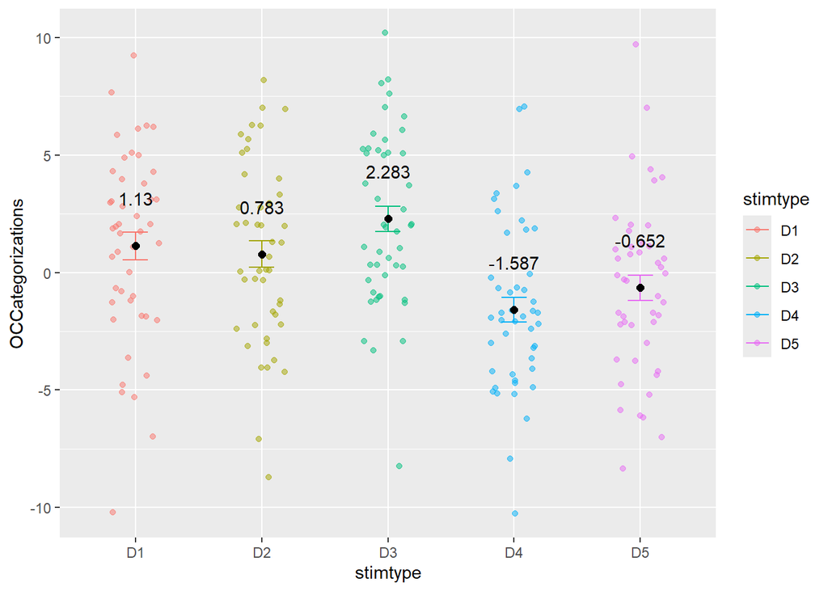

# Mixed models

## Mixed models

```
## Generalized linear mixed model fit by maximum likelihood (Laplace
##   Approximation) [glmerMod]
##  Family: binomial  ( logit )
## Formula: rt_resp ~ stimtype * test_quality + (1 | workerId)
##    Data: tdlmm
##
##       AIC       BIC    logLik -2*log(L)  df.resid
##    5414.8    5484.8   -2696.4    5392.8      4291
##
## Scaled residuals:
##     Min      1Q  Median      3Q     Max
## -4.9548 -0.9301  0.4576  0.8294  2.3078
##
## Random effects:
##  Groups   Name        Variance Std.Dev.
##  workerId (Intercept) 0.4764   0.6902
## Number of obs: 4302, groups:  workerId, 46
##
## Fixed effects:
##                            Estimate Std. Error z value Pr(>|z|)
## (Intercept)                -0.39610    0.14519  -2.728  0.00637 **
## stimtypeD2                  0.44190    0.14401   3.068  0.00215 **
## stimtypeD3                  0.59707    0.14503   4.117 3.84e-05 ***
## stimtypeD4                  0.83713    0.14542   5.757 8.57e-09 ***
## stimtypeD5                  1.75382    0.15760  11.128  < 2e-16 ***
## test_qualitynew             0.25920    0.14454   1.793  0.07294 .
## stimtypeD2:test_qualitynew -0.08771    0.20253  -0.433  0.66497
## stimtypeD3:test_qualitynew  0.29042    0.20563   1.412  0.15785
## stimtypeD4:test_qualitynew -0.64016    0.20415  -3.136  0.00171 **
## stimtypeD5:test_qualitynew -0.45082    0.21819  -2.066  0.03881 *
## ---
## Signif. codes:  0 '***' 0.001 '**' 0.01 '*' 0.05 '.' 0.1 ' ' 1
##
## Correlation of Fixed Effects:
##             (Intr) stmtD2 stmtD3 stmtD4 stmtD5 tst_ql stD2:_ stD3:_ stD4:_
## stimtypeD2  -0.510
## stimtypeD3  -0.506  0.512
## stimtypeD4  -0.505  0.511  0.507
## stimtypeD5  -0.466  0.472  0.469  0.469
## test_qltynw -0.508  0.513  0.510  0.508  0.469
## stmtypD2:t_  0.363 -0.711 -0.364 -0.363 -0.335 -0.714
## stmtypD3:t_  0.357 -0.360 -0.705 -0.356 -0.329 -0.703  0.502
## stmtypD4:t_  0.360 -0.364 -0.361 -0.712 -0.333 -0.708  0.505  0.497
## stmtypD5:t_  0.337 -0.340 -0.338 -0.337 -0.719 -0.662  0.473  0.466  0.469
```

```
## You are calculating adjusted predictions on the population-level (i.e.
##   `type = "fixed"`) for a *generalized* linear mixed model.
##   This may produce biased estimates due to Jensen's inequality. Consider
##   setting `bias_correction = TRUE` to correct for this bias.
##   See also the documentation of the `bias_correction` argument.
```

```
## Ignoring unknown labels:
## • linetype : "test_quality"
## • shape : "test_quality"
```

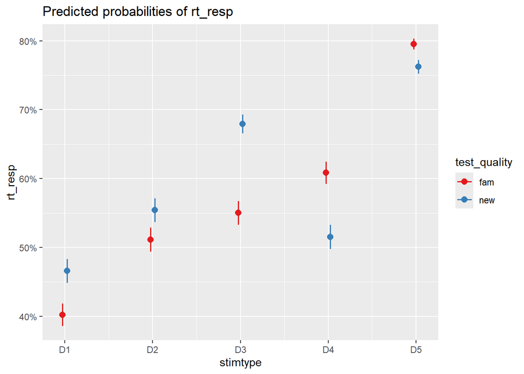

```
## $emmeans
## stimtype = D1:
##  test_quality  emmean    SE  df asymp.LCL asymp.UCL
##  fam          -0.3961 0.145 Inf   -0.6807    -0.112
##  new          -0.1369 0.144 Inf   -0.4185     0.145
##
## stimtype = D2:
##  test_quality  emmean    SE  df asymp.LCL asymp.UCL
##  fam           0.0458 0.143 Inf   -0.2347     0.326
##  new           0.2173 0.143 Inf   -0.0635     0.498
##
## stimtype = D3:
##  test_quality  emmean    SE  df asymp.LCL asymp.UCL
##  fam           0.2010 0.144 Inf   -0.0816     0.484
##  new           0.7506 0.147 Inf    0.4631     1.038
##
## stimtype = D4:
##  test_quality  emmean    SE  df asymp.LCL asymp.UCL
##  fam           0.4410 0.145 Inf    0.1577     0.724
##  new           0.0601 0.144 Inf   -0.2224     0.343
##
## stimtype = D5:
##  test_quality  emmean    SE  df asymp.LCL asymp.UCL
##  fam           1.3577 0.157 Inf    1.0504     1.665
##  new           1.1661 0.152 Inf    0.8674     1.465
##
## Results are given on the logit (not the response) scale.
## Confidence level used: 0.95
##
## $contrasts
## stimtype = D1:
##  contrast  estimate    SE  df z.ratio p.value
##  fam - new   -0.259 0.145 Inf  -1.793  0.0729
##
## stimtype = D2:
##  contrast  estimate    SE  df z.ratio p.value
##  fam - new   -0.171 0.142 Inf  -1.209  0.2267
##
## stimtype = D3:
##  contrast  estimate    SE  df z.ratio p.value
##  fam - new   -0.550 0.146 Inf  -3.757  0.0002
##
## stimtype = D4:
##  contrast  estimate    SE  df z.ratio p.value
##  fam - new    0.381 0.144 Inf   2.643  0.0082
##
## stimtype = D5:
##  contrast  estimate    SE  df z.ratio p.value
##  fam - new    0.192 0.163 Inf   1.172  0.2410
##
## Results are given on the log odds ratio (not the response) scale.
```

```
## Generalized linear mixed model fit by maximum likelihood (Laplace
##   Approximation) [glmerMod]
##  Family: binomial  ( logit )
## Formula: rt_resp ~ DTF * test_quality + (1 | workerId)
##    Data: tdlmm
##
##       AIC       BIC    logLik -2*log(L)  df.resid
##    5649.5    5681.3   -2819.7    5639.5      4297
##
## Scaled residuals:
##     Min      1Q  Median      3Q     Max
## -3.2713 -1.0194  0.6054  0.8724  1.5491
##
## Random effects:
##  Groups   Name        Variance Std.Dev.
##  workerId (Intercept) 0.3918   0.6259
## Number of obs: 4302, groups:  workerId, 46
##
## Fixed effects:
##                     Estimate Std. Error z value Pr(>|z|)
## (Intercept)          0.14273    0.15457   0.923    0.356
## DTF                  0.03467    0.02547   1.361    0.174
## test_qualitynew     -0.01915    0.09579  -0.200    0.842
## DTF:test_qualitynew  0.02489    0.01639   1.519    0.129
##
## Correlation of Fixed Effects:
##             (Intr) DTF    tst_ql
## DTF         -0.745
## test_qltynw -0.308  0.234
## DTF:tst_qlt  0.226 -0.308 -0.744
```

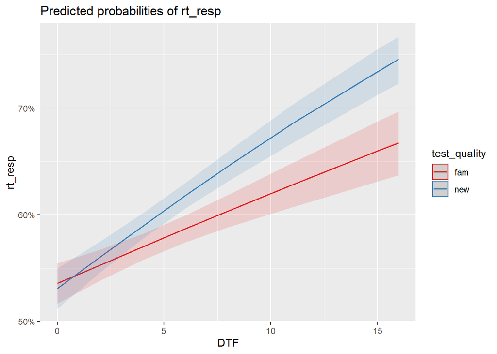

```
## Generalized linear mixed model fit by maximum likelihood (Laplace
##   Approximation) [glmerMod]
##  Family: binomial  ( logit )
## Formula: rt_resp ~ DTAF * test_quality + (1 | workerId)
##    Data: tdlmm
##
##       AIC       BIC    logLik -2*log(L)  df.resid
##    5648.7    5680.6   -2819.4    5638.7      4297
##
## Scaled residuals:
##     Min      1Q  Median      3Q     Max
## -3.0712 -1.0279  0.5750  0.8685  1.5913
##
## Random effects:
##  Groups   Name        Variance Std.Dev.
##  workerId (Intercept) 0.4323   0.6575
## Number of obs: 4302, groups:  workerId, 46
##
## Fixed effects:
##                      Estimate Std. Error z value Pr(>|z|)
## (Intercept)           0.44266    0.24879   1.779  0.07520 .
## DTAF                 -0.01302    0.02089  -0.623  0.53324
## test_qualitynew      -0.25075    0.14649  -1.712  0.08695 .
## DTAF:test_qualitynew  0.03189    0.01236   2.580  0.00988 **
## ---
## Signif. codes:  0 '***' 0.001 '**' 0.01 '*' 0.05 '.' 0.1 ' ' 1
##
## Correlation of Fixed Effects:
##             (Intr) DTAF   tst_ql
## DTAF        -0.902
## test_qltynw -0.303  0.273
## DTAF:tst_ql  0.272 -0.301 -0.899
```

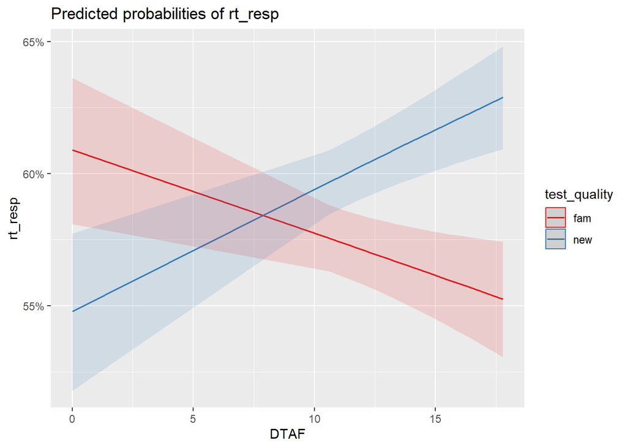

```
## Generalized linear mixed model fit by maximum likelihood (Laplace
##   Approximation) [glmerMod]
##  Family: binomial  ( logit )
## Formula: rt_resp ~ DTAN * test_quality + (1 | workerId)
##    Data: tdlmm
##
##       AIC       BIC    logLik -2*log(L)  df.resid
##    5648.5    5680.4   -2819.3    5638.5      4297
##
## Scaled residuals:
##     Min      1Q  Median      3Q     Max
## -2.9825 -1.0285  0.5708  0.8707  1.6034
##
## Random effects:
##  Groups   Name        Variance Std.Dev.
##  workerId (Intercept) 0.431    0.6565
## Number of obs: 4302, groups:  workerId, 46
##
## Fixed effects:
##                      Estimate Std. Error z value Pr(>|z|)
## (Intercept)           0.52763    0.25350   2.081  0.03740 *
## DTAN                 -0.01990    0.02035  -0.978  0.32829
## test_qualitynew      -0.26275    0.14928  -1.760  0.07839 .
## DTAN:test_qualitynew  0.03134    0.01201   2.610  0.00905 **
## ---
## Signif. codes:  0 '***' 0.001 '**' 0.01 '*' 0.05 '.' 0.1 ' ' 1
##
## Correlation of Fixed Effects:
##             (Intr) DTAN   tst_ql
## DTAN        -0.906
## test_qltynw -0.304  0.275
## DTAN:tst_ql  0.275 -0.302 -0.903
## optimizer (Nelder_Mead) convergence code: 0 (OK)
## Model failed to converge with max|grad| = 0.00251161 (tol = 0.002, component 1)
##   See ?lme4::convergence and ?lme4::troubleshooting.
```

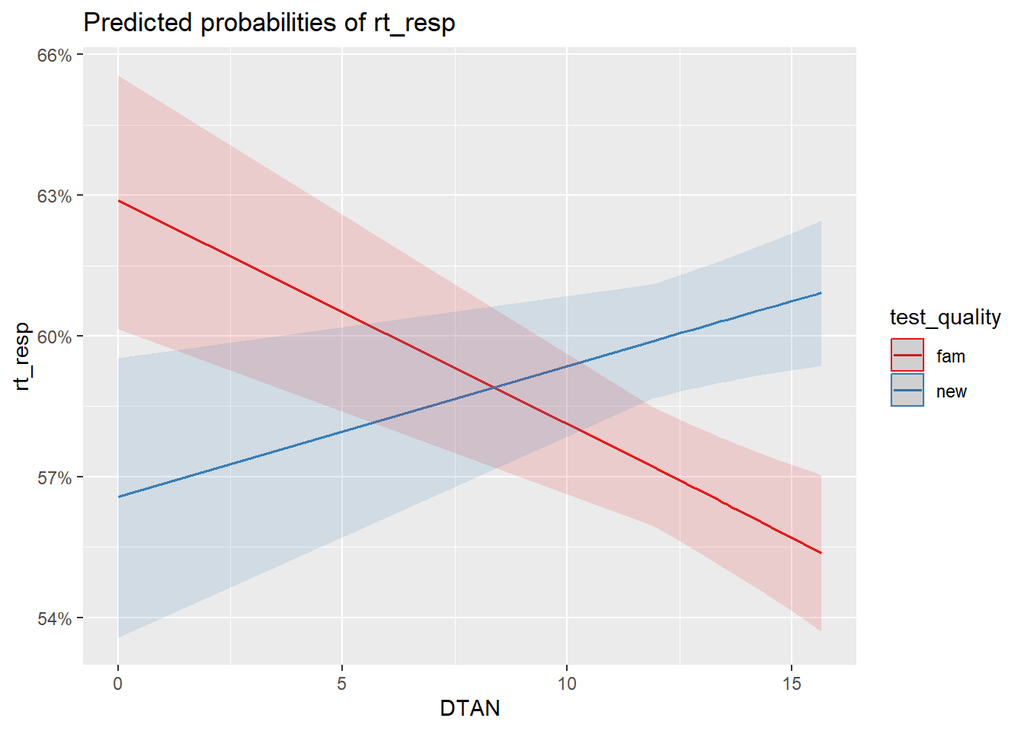

```
## Generalized linear mixed model fit by maximum likelihood (Laplace
##   Approximation) [glmerMod]
##  Family: binomial  ( logit )
## Formula: rt_resp ~ DTN * test_quality + (1 | workerId)
##    Data: tdlmm
##
##       AIC       BIC    logLik -2*log(L)  df.resid
##    5648.7    5680.5   -2819.3    5638.7      4297
##
## Scaled residuals:
##     Min      1Q  Median      3Q     Max
## -2.9935 -1.0300  0.5716  0.8703  1.6004
##
## Random effects:
##  Groups   Name        Variance Std.Dev.
##  workerId (Intercept) 0.4314   0.6568
## Number of obs: 4302, groups:  workerId, 46
##
## Fixed effects:
##                     Estimate Std. Error z value Pr(>|z|)
## (Intercept)          0.51098    0.25374   2.014  0.04403 *
## DTN                 -0.01909    0.02110  -0.905  0.36571
## test_qualitynew     -0.26024    0.14932  -1.743  0.08135 .
## DTN:test_qualitynew  0.03225    0.01245   2.591  0.00958 **
## ---
## Signif. codes:  0 '***' 0.001 '**' 0.01 '*' 0.05 '.' 0.1 ' ' 1
##
## Correlation of Fixed Effects:
##             (Intr) DTN    tst_ql
## DTN         -0.906
## test_qltynw -0.304  0.275
## DTN:tst_qlt  0.274 -0.302 -0.903
## optimizer (Nelder_Mead) convergence code: 0 (OK)
## Model failed to converge with max|grad| = 0.00408555 (tol = 0.002, component 1)
##   See ?lme4::convergence and ?lme4::troubleshooting.
```

```
## Data were 'prettified'. Consider using `terms="DTN [all]"` to get smooth
##   plots.
```

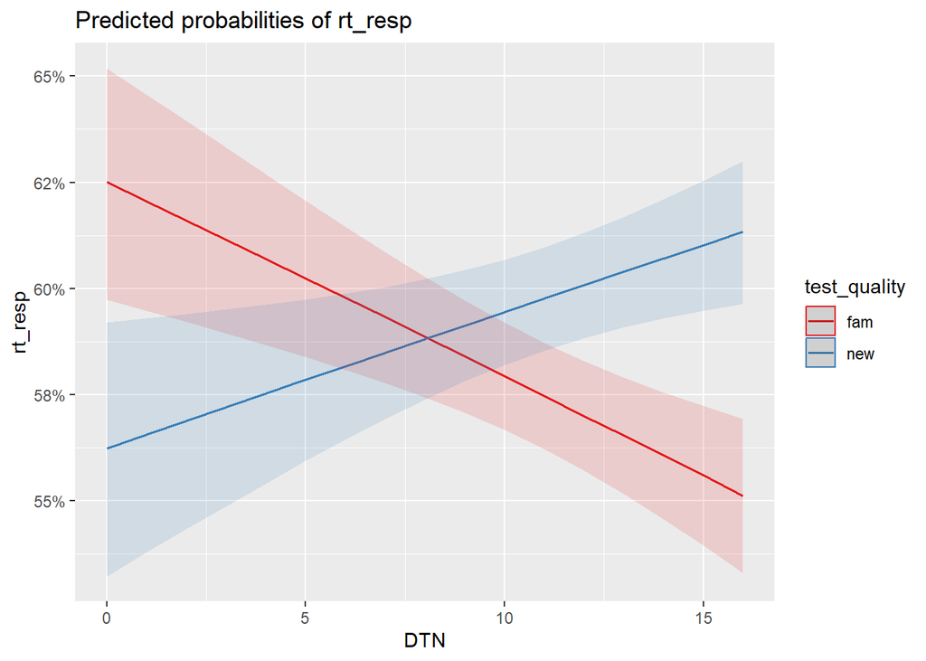

|  | rt_resp |  |  |  | rt_resp |  |  |  | rt_resp |  |  |  | rt_resp |  |  |  | rt_resp |  |  |  |
| --- | --- | --- | --- | --- | --- | --- | --- | --- | --- | --- | --- | --- | --- | --- | --- | --- | --- | --- | --- | --- |
| Predictors | Log-Odds | std. Error | CI | p | Log-Odds | std. Error | CI | p | Log-Odds | std. Error | CI | p | Log-Odds | std. Error | CI | p | Log-Odds | std. Error | CI | p |
| (Intercept) | -0.40 | 0.15 | -0.68 – -0.11 | **0.006** | 0.14 | 0.15 | -0.16 – 0.45 | 0.356 | 0.44 | 0.25 | -0.04 – 0.93 | 0.075 | 0.53 | 0.25 | 0.03 – 1.02 | **0.037** | 0.51 | 0.25 | 0.01 – 1.01 | **0.044** |
| stimtype [D2] | 0.44 | 0.14 | 0.16 – 0.72 | **0.002** |  |  |  |  |  |  |  |  |  |  |  |  |  |  |  |  |
| stimtype [D3] | 0.60 | 0.15 | 0.31 – 0.88 | **<0.001** |  |  |  |  |  |  |  |  |  |  |  |  |  |  |  |  |
| stimtype [D4] | 0.84 | 0.15 | 0.55 – 1.12 | **<0.001** |  |  |  |  |  |  |  |  |  |  |  |  |  |  |  |  |
| stimtype [D5] | 1.75 | 0.16 | 1.44 – 2.06 | **<0.001** |  |  |  |  |  |  |  |  |  |  |  |  |  |  |  |  |
| test quality [new] | 0.26 | 0.14 | -0.02 – 0.54 | 0.073 | -0.02 | 0.10 | -0.21 – 0.17 | 0.842 | -0.25 | 0.15 | -0.54 – 0.04 | 0.087 | -0.26 | 0.15 | -0.56 – 0.03 | 0.078 | -0.26 | 0.15 | -0.55 – 0.03 | 0.081 |
| stimtype [D2] × test quality [new] | -0.09 | 0.20 | -0.48 – 0.31 | 0.665 |  |  |  |  |  |  |  |  |  |  |  |  |  |  |  |  |
| stimtype [D3] × test quality [new] | 0.29 | 0.21 | -0.11 – 0.69 | 0.158 |  |  |  |  |  |  |  |  |  |  |  |  |  |  |  |  |
| stimtype [D4] × test quality [new] | -0.64 | 0.20 | -1.04 – -0.24 | **0.002** |  |  |  |  |  |  |  |  |  |  |  |  |  |  |  |  |
| stimtype [D5] × test quality [new] | -0.45 | 0.22 | -0.88 – -0.02 | **0.039** |  |  |  |  |  |  |  |  |  |  |  |  |  |  |  |  |
| DTF |  |  |  |  | 0.03 | 0.03 | -0.02 – 0.08 | 0.174 |  |  |  |  |  |  |  |  |  |  |  |  |
| DTF × test quality [new] |  |  |  |  | 0.02 | 0.02 | -0.01 – 0.06 | 0.129 |  |  |  |  |  |  |  |  |  |  |  |  |
| DTAF |  |  |  |  |  |  |  |  | -0.01 | 0.02 | -0.05 – 0.03 | 0.533 |  |  |  |  |  |  |  |  |
| DTAF × test quality [new] |  |  |  |  |  |  |  |  | 0.03 | 0.01 | 0.01 – 0.06 | **0.010** |  |  |  |  |  |  |  |  |
| DTAN |  |  |  |  |  |  |  |  |  |  |  |  | -0.02 | 0.02 | -0.06 – 0.02 | 0.328 |  |  |  |  |
| DTAN × test quality [new] |  |  |  |  |  |  |  |  |  |  |  |  | 0.03 | 0.01 | 0.01 – 0.05 | **0.009** |  |  |  |  |
| DTN |  |  |  |  |  |  |  |  |  |  |  |  |  |  |  |  | -0.02 | 0.02 | -0.06 – 0.02 | 0.366 |
| DTN × test quality [new] |  |  |  |  |  |  |  |  |  |  |  |  |  |  |  |  | 0.03 | 0.01 | 0.01 – 0.06 | **0.010** |
| Random Effects |  |  |  |  |  |  |  |  |  |  |  |  |  |  |  |  |  |  |  |  |
| σ<sup>2</sup> | 3.29 |  |  |  | 3.29 |  |  |  | 3.29 |  |  |  | 3.29 |  |  |  | 3.29 |  |  |  |
| τ<sub>00</sub> | 0.48 <sub>workerId</sub> |  |  |  | 0.39 <sub>workerId</sub> |  |  |  | 0.43 <sub>workerId</sub> |  |  |  | 0.43 <sub>workerId</sub> |  |  |  | 0.43 <sub>workerId</sub> |  |  |  |
| ICC | 0.13 |  |  |  | 0.11 |  |  |  | 0.12 |  |  |  | 0.12 |  |  |  | 0.12 |  |  |  |
| N | 46 <sub>workerId</sub> |  |  |  | 46 <sub>workerId</sub> |  |  |  | 46 <sub>workerId</sub> |  |  |  | 46 <sub>workerId</sub> |  |  |  | 46 <sub>workerId</sub> |  |  |  |
| Observations | 4302 |  |  |  | 4302 |  |  |  | 4302 |  |  |  | 4302 |  |  |  | 4302 |  |  |  |
| Marginal R<sup>2</sup> / Conditional R<sup>2</sup> | 0.071 / 0.188 |  |  |  | 0.011 / 0.116 |  |  |  | 0.002 / 0.118 |  |  |  | 0.003 / 0.118 |  |  |  | 0.002 / 0.118 |  |  |  |
| AIC | 5414.807 |  |  |  | 5649.499 |  |  |  | 5648.719 |  |  |  | 5648.543 |  |  |  | 5648.668 |  |  |  |
| AICc | 5414.869 |  |  |  | 5649.513 |  |  |  | 5648.733 |  |  |  | 5648.557 |  |  |  | 5648.682 |  |  |  |

## ALT - Mixed models

Use sum-to-zero contrasts so that coefficients are interpreted as deviations from the grand mean rather than comparisons with the reference level (D1). This is useful when no stimulus type serves as a theoretically meaningful baseline condition.

```
## Generalized linear mixed model fit by maximum likelihood (Laplace
##   Approximation) [glmerMod]
##  Family: binomial  ( logit )
## Formula: rt_resp ~ stimtype * test_quality + (1 | workerId)
##    Data: tdlmm
##
##       AIC       BIC    logLik -2*log(L)  df.resid
##    5414.8    5484.8   -2696.4    5392.8      4291
##
## Scaled residuals:
##     Min      1Q  Median      3Q     Max
## -4.9548 -0.9301  0.4576  0.8294  2.3079
##
## Random effects:
##  Groups   Name        Variance Std.Dev.
##  workerId (Intercept) 0.4765   0.6903
## Number of obs: 4302, groups:  workerId, 46
##
## Fixed effects:
##                         Estimate Std. Error z value Pr(>|z|)
## (Intercept)              0.37064    0.10747   3.449 0.000563 ***
## stimtype1               -0.63718    0.06522  -9.769  < 2e-16 ***
## stimtype2               -0.23909    0.06418  -3.725 0.000195 ***
## stimtype3                0.10511    0.06561   1.602 0.109154
## stimtype4               -0.12008    0.06493  -1.849 0.064415 .
## test_quality1           -0.04077    0.03315  -1.230 0.218715
## stimtype1:test_quality1 -0.08884    0.06506  -1.365 0.172098
## stimtype2:test_quality1 -0.04497    0.06417  -0.701 0.483404
## stimtype3:test_quality1 -0.23402    0.06565  -3.565 0.000364 ***
## stimtype4:test_quality1  0.23125    0.06494   3.561 0.000370 ***
## ---
## Signif. codes:  0 '***' 0.001 '**' 0.01 '*' 0.05 '.' 0.1 ' ' 1
##
## Correlation of Fixed Effects:
##             (Intr) stmty1 stmty2 stmty3 stmty4 tst_q1 st1:_1 st2:_1 st3:_1
## stimtype1   -0.012
## stimtype2   -0.014 -0.226
## stimtype3   -0.004 -0.238 -0.232
## stimtype4   -0.009 -0.232 -0.227 -0.237
## test_qulty1  0.003  0.006 -0.006 -0.021 -0.004
## stmtyp1:t_1  0.001  0.019 -0.002  0.005 -0.003 -0.025
## stmtyp2:t_1 -0.002 -0.002  0.002  0.011  0.002 -0.043 -0.228
## stmtyp3:t_1 -0.008  0.007  0.012 -0.021  0.010 -0.014 -0.237 -0.232
## stmtyp4:t_1  0.001 -0.006  0.001  0.010  0.006 -0.028 -0.233 -0.227 -0.238
```

## image effects

```
## Generalized linear mixed model fit by maximum likelihood (Laplace
##   Approximation) [glmerMod]
##  Family: binomial  ( logit )
## Formula: rt_resp ~ stimtype * test_quality + (1 | workerId) + (1 | stim)
##    Data: tdlmm
##
##       AIC       BIC    logLik -2*log(L)  df.resid
##    5303.4    5379.8   -2639.7    5279.4      4290
##
## Scaled residuals:
##     Min      1Q  Median      3Q     Max
## -5.9269 -0.8528  0.4119  0.7724  2.5660
##
## Random effects:
##  Groups   Name        Variance Std.Dev.
##  stim     (Intercept) 0.2703   0.5199
##  workerId (Intercept) 0.5387   0.7340
## Number of obs: 4302, groups:  stim, 100; workerId, 46
##
## Fixed effects:
##                         Estimate Std. Error z value Pr(>|z|)
## (Intercept)              0.38801    0.12522   3.099  0.00194 **
## stimtype1               -0.67408    0.12389  -5.441  5.3e-08 ***
## stimtype2               -0.25384    0.12320  -2.060  0.03935 *
## stimtype3                0.12690    0.12436   1.020  0.30751
## stimtype4               -0.12709    0.12362  -1.028  0.30390
## test_quality1           -0.04416    0.06222  -0.710  0.47787
## stimtype1:test_quality1 -0.10147    0.12375  -0.820  0.41223
## stimtype2:test_quality1 -0.03844    0.12318  -0.312  0.75498
## stimtype3:test_quality1 -0.25611    0.12439  -2.059  0.03950 *
## stimtype4:test_quality1  0.24319    0.12362   1.967  0.04915 *
## ---
## Signif. codes:  0 '***' 0.001 '**' 0.01 '*' 0.05 '.' 0.1 ' ' 1
##
## Correlation of Fixed Effects:
##             (Intr) stmty1 stmty2 stmty3 stmty4 tst_q1 st1:_1 st2:_1 st3:_1
## stimtype1   -0.006
## stimtype2   -0.007 -0.242
## stimtype3    0.000 -0.248 -0.246
## stimtype4   -0.005 -0.244 -0.243 -0.247
## test_qulty1  0.001  0.003 -0.002 -0.010  0.000
## stmtyp1:t_1  0.001  0.008 -0.001  0.003 -0.002 -0.007
## stmtyp2:t_1 -0.001 -0.001  0.000  0.006  0.000 -0.013 -0.243
## stmtyp3:t_1 -0.006  0.004  0.006 -0.012  0.005 -0.001 -0.247 -0.245
## stmtyp4:t_1  0.001 -0.003  0.000  0.005  0.003 -0.009 -0.245 -0.243 -0.247
```

```
## $emmeans
## stimtype = D1:
##  test_quality  emmean    SE  df asymp.LCL asymp.UCL
##  fam          -0.4317 0.224 Inf   -0.8710    0.0076
##  new          -0.1404 0.223 Inf   -0.5769    0.2960
##
## stimtype = D2:
##  test_quality  emmean    SE  df asymp.LCL asymp.UCL
##  fam           0.0516 0.222 Inf   -0.3841    0.4872
##  new           0.2168 0.223 Inf   -0.2195    0.6530
##
## stimtype = D3:
##  test_quality  emmean    SE  df asymp.LCL asymp.UCL
##  fam           0.2146 0.223 Inf   -0.2226    0.6519
##  new           0.8152 0.226 Inf    0.3717    1.2586
##
## stimtype = D4:
##  test_quality  emmean    SE  df asymp.LCL asymp.UCL
##  fam           0.4600 0.223 Inf    0.0219    0.8980
##  new           0.0619 0.223 Inf   -0.3751    0.4989
##
## stimtype = D5:
##  test_quality  emmean    SE  df asymp.LCL asymp.UCL
##  fam           1.4248 0.232 Inf    0.9698    1.8798
##  new           1.2075 0.228 Inf    0.7600    1.6549
##
## Results are given on the logit (not the response) scale.
## Confidence level used: 0.95
##
## $contrasts
## stimtype = D1:
##  contrast  estimate    SE  df z.ratio p.value
##  fam - new   -0.291 0.276 Inf  -1.055  0.2916
##
## stimtype = D2:
##  contrast  estimate    SE  df z.ratio p.value
##  fam - new   -0.165 0.274 Inf  -0.602  0.5473
##
## stimtype = D3:
##  contrast  estimate    SE  df z.ratio p.value
##  fam - new   -0.601 0.278 Inf  -2.160  0.0308
##
## stimtype = D4:
##  contrast  estimate    SE  df z.ratio p.value
##  fam - new    0.398 0.276 Inf   1.443  0.1489
##
## stimtype = D5:
##  contrast  estimate    SE  df z.ratio p.value
##  fam - new    0.217 0.287 Inf   0.758  0.4482
##
## Results are given on the log odds ratio (not the response) scale.
```

## is the interaction significant?

```
## Data: tdlmm
## Models:
## mod_no_interaction: rt_resp ~ stimtype + test_quality + (1 | workerId) + (1 | stim)
## mod_img: rt_resp ~ stimtype * test_quality + (1 | workerId) + (1 | stim)
##                    npar    AIC    BIC  logLik -2*log(L)  Chisq Df Pr(>Chisq)
## mod_no_interaction    8 5303.4 5354.3 -2643.7    5287.4
## mod_img              12 5303.4 5379.8 -2639.7    5279.4 7.9689  4    0.09273 .
## ---
## Signif. codes:  0 '***' 0.001 '**' 0.01 '*' 0.05 '.' 0.1 ' ' 1
```